# R Notebook

## Libraries and Data

```r
load.libraries <- c('data.table', 'testthat', 'gridExtra', 'corrplot', 'GGally', 'ggplot2', 'e1071', 'dplyr')
install.lib <- load.libraries[!load.libraries %in% installed.packages()]
for(libs in install.lib) install.packages(libs, dependences = TRUE)
sapply(load.libraries, require, character = TRUE)
```

```
data.table   testthat  gridExtra   corrplot     GGally    ggplot2      e1071      dplyr
      TRUE       TRUE       TRUE       TRUE       TRUE       TRUE       TRUE       TRUE
```

```r
library(data.table)
library(ggplot2) #data visualization
library(plotly) #interactive data visualization
library(psych) #correlation visualization helping
library(rattle) #graphing decesiion trees
library(caret) # machine learning
library(tree)
library(e1071)
library(rpart)
library(magrittr) # needs to be run every time you start R and want to use %>%
library(dplyr)    # alternatively, this also loads %>%
library(class)
library(formattable)
data <- read.csv("data.csv")
setDT(data)
```

### Missing Value plot

```r
plot_Missing <- function(data_in, title = NULL){
  temp_df <- as.data.frame(ifelse(is.na(data_in), 0, 1))
  temp_df <- temp_df[,order(colSums(temp_df))]
  data_temp <- expand.grid(list(x = 1:nrow(temp_df), y = colnames(temp_df)))
  data_temp$m <- as.vector(as.matrix(temp_df))
  data_temp <- data.frame(x = unlist(data_temp$x), y = unlist(data_temp$y), m = unlist(data_temp$m))
  ggplot(data_temp) + geom_tile(aes(x=x, y=y, fill=factor(m))) + scale_fill_manual(values=c("white", "black"), name="Missing\n(0=Yes, 1=No)") + theme_light() + ylab("") + xlab("") + ggtitle(title)
}
```

### Selected features covering post 2010

```r
df1 <- data %>%
  select(date, Winner, title_bout, weight_class,B_fighter, B_Height_cms, B_Reach_cms, B_age, B_current_lose_streak, B_current_win_streak,B_longest_win_streak, B_losses,B_wins,B_total_rounds_fought, B_total_title_bouts,B_win_by_KO.TKO,B_win_by_Submission, B_win_by_Decision_Majority,B_win_by_Decision_Split,B_win_by_Decision_Unanimous,B_win_by_TKO_Doctor_Stoppage,
         R_fighter, R_Height_cms, R_Reach_cms, R_age,
         R_current_lose_streak, R_current_win_streak,R_longest_win_streak, R_losses,R_wins,R_total_rounds_fought,
         R_total_title_bouts,R_win_by_KO.TKO,R_win_by_Submission,
         R_win_by_Decision_Majority,R_win_by_Decision_Split,R_win_by_Decision_Unanimous,R_win_by_TKO_Doctor_Stoppage)


df1 <- subset.data.frame(df1, subset= date >= "2010-01-01")
```

*Dimension of new dataset*

```r
dim(df1)
```

```
[1] 3897   38
```

*Null Value Plot*

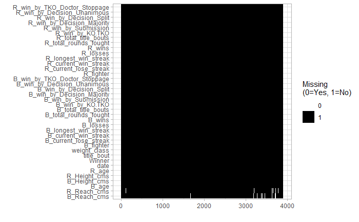

```r
plot_Missing(df1[,colSums(is.na(df1)) >= 0, with = FALSE])
```

### Detection of null values

```r
cat_var1 <- names(df1)[which(sapply(df1, is.character))] #kategorik
numeric_var1 <- names(df1)[which(sapply(df1, is.numeric))] #numeric
colSums(sapply(df1[,.SD, .SDcols = cat_var1], is.na))
```

```
        date       Winner   title_bout weight_class    B_fighter    R_fighter
           0            0            0            0            0            0
```

```r
colSums(sapply(df1[,.SD, .SDcols = numeric_var1], is.na)) #numericte null kontrolu
```

```
                B_Height_cms                  B_Reach_cms                        B_age        B_current_lose_streak
                           2                           97                            7                            0
        B_current_win_streak         B_longest_win_streak                     B_losses                       B_wins
                           0                            0                            0                            0
       B_total_rounds_fought          B_total_title_bouts              B_win_by_KO.TKO          B_win_by_Submission
                           0                            0                            0                            0
  B_win_by_Decision_Majority      B_win_by_Decision_Split  B_win_by_Decision_Unanimous B_win_by_TKO_Doctor_Stoppage
                           0                            0                            0                            0
                R_Height_cms                  R_Reach_cms                        R_age        R_current_lose_streak
                           2                           39                            2                            0
        R_current_win_streak         R_longest_win_streak                     R_losses                       R_wins
                           0                            0                            0                            0
       R_total_rounds_fought          R_total_title_bouts              R_win_by_KO.TKO          R_win_by_Submission
                           0                            0                            0                            0
  R_win_by_Decision_Majority      R_win_by_Decision_Split  R_win_by_Decision_Unanimous R_win_by_TKO_Doctor_Stoppage
                           0                            0                            0                            0
```

###New dataset where null values are deleted

```r
df2 <- na.omit(df1) ##null rowlari sildi

cat_var2 <- names(df2)[which(sapply(df2, is.character))] #kategorik
numeric_var2 <- names(df2)[which(sapply(df2, is.numeric))] #numeric
colSums(sapply(df2[,.SD, .SDcols = cat_var2], is.na)) #kategorikte null kontrolu
```

```
        date       Winner   title_bout weight_class    B_fighter    R_fighter
           0            0            0            0            0            0
```

```r
colSums(sapply(df2[,.SD, .SDcols = numeric_var2], is.na)) #numericte null kontrolu
```

```
                B_Height_cms                  B_Reach_cms                        B_age        B_current_lose_streak
                           0                            0                            0                            0
        B_current_win_streak         B_longest_win_streak                     B_losses                       B_wins
                           0                            0                            0                            0
       B_total_rounds_fought          B_total_title_bouts              B_win_by_KO.TKO          B_win_by_Submission
                           0                            0                            0                            0
  B_win_by_Decision_Majority      B_win_by_Decision_Split  B_win_by_Decision_Unanimous B_win_by_TKO_Doctor_Stoppage
                           0                            0                            0                            0
                R_Height_cms                  R_Reach_cms                        R_age        R_current_lose_streak
                           0                            0                            0                            0
        R_current_win_streak         R_longest_win_streak                     R_losses                       R_wins
                           0                            0                            0                            0
       R_total_rounds_fought          R_total_title_bouts              R_win_by_KO.TKO          R_win_by_Submission
                           0                            0                            0                            0
  R_win_by_Decision_Majority      R_win_by_Decision_Split  R_win_by_Decision_Unanimous R_win_by_TKO_Doctor_Stoppage
                           0                            0                            0                            0
```

```r
dim(df1)
```

```
[1] 3897   38
```

*Null Value Plot of final dataset*

[figure not shown]

```r
plot_Missing(df2[,colSums(is.na(df2)) >= 0, with = FALSE])
```

### Visualization of numeric column information

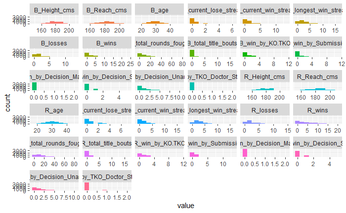

```r
plot_num(df2)
```

### Histogram for Blue Fighter Reach Difference

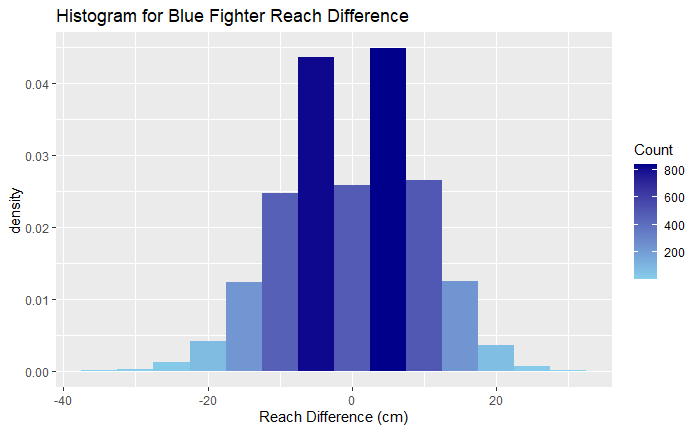

```r
ggplot(df2, aes(x=(B_Reach_cms - R_Reach_cms), y =..density.., fill=..count..)) + geom_histogram(binwidth = 5, ) + labs(x = "Reach Difference (cm)", title = "Histogram for Blue Fighter Reach Difference") + scale_fill_gradient("Count", low="#87CEEB", high="#00008B")
```

### Histogram for Red Fighter Reach Difference

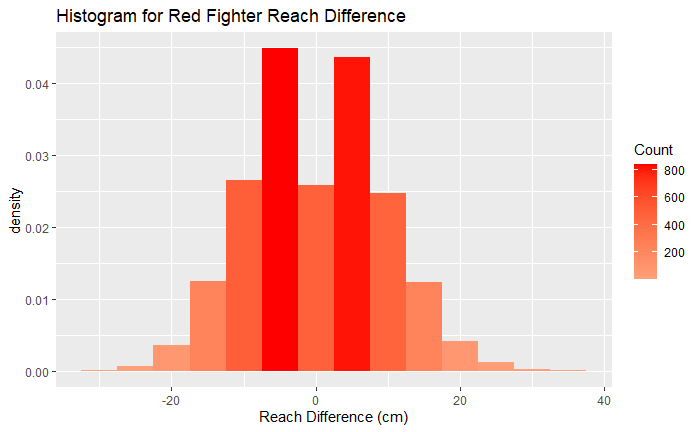

```r
ggplot(df2, aes(x=(R_Reach_cms - B_Reach_cms), y =..density.., fill=..count..)) + geom_histogram(binwidth = 5, ) + labs(x = "Reach Difference (cm)", title = "Histogram for Red Fighter Reach Difference") + scale_fill_gradient("Count", low="#FFA07A", high="#FF0000")
```

### Barplot of Blue Fighter Age

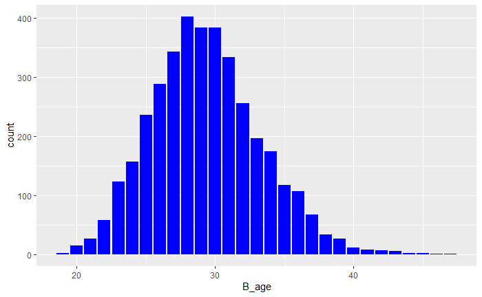

```r
ggplot(df2, aes(x = B_age)) + geom_bar(fill = "#0000FF") #B_age
```

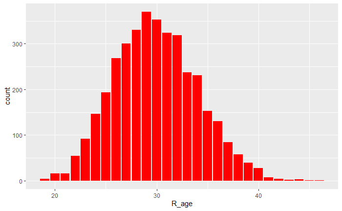

```r
ggplot(df2, aes(x = R_age)) + geom_bar(fill = "#FF0000") #R_age
```

### List of Blue fighter’s winning average

```r
temp <- df2 %>% select(B_fighter,B_wins)
temp <- temp %>% group_by(B_fighter) %>% summarise(avg=mean(B_wins))
temp <- temp %>% arrange(desc(avg))
temp <- temp[1:10,]
temp %>%
  formattable(list(avg = color_bar("#85C1E9")), align = 'l')
```

| B_fighter | avg |
| --- | --- |
| Georges St-Pierre | 19.00000 |
| Anderson Silva | 16.50000 |
| Randy Couture | 16.00000 |
| Frank Mir | 15.00000 |
| Tito Ortiz | 15.00000 |
| Diego Sanchez | 14.20000 |
| Jim Miller | 14.00000 |
| Josh Koscheck | 14.00000 |
| Michael Bisping | 13.83333 |
| Andrei Arlovski | 13.33333 |

### List of Red fighter’s winning average

```r
temp <- df2 %>% select(R_fighter,R_wins)
temp <- temp %>% group_by(R_fighter) %>% summarise(avg=mean(R_wins))
temp <- temp %>% arrange(desc(avg))
temp <- temp[1:10,]
temp %>%
  formattable(list(avg = color_bar("#FF0000")), align = 'l')
```

| R_fighter | avg |
| --- | --- |
| Matt Hughes | 17.66667 |
| Chuck Liddell | 16.00000 |
| Georges St-Pierre | 15.50000 |
| Andrei Arlovski | 14.33333 |
| Tito Ortiz | 14.33333 |
| Josh Koscheck | 14.20000 |
| Randy Couture | 14.00000 |
| Rich Franklin | 14.00000 |
| Michael Bisping | 13.92308 |
| Anderson Silva | 13.90000 |

##The winning Blue fighter according to weight_class

```r
df2 %>% filter(Winner == "Blue") %>% count(weight_class) #weight_class'a göre kazanan blue
```

| weight_class | n |
| --- | --- |
| Bantamweight | 152 |
| Catch Weight | 5 |
| Featherweight | 171 |
| Flyweight | 69 |
| Heavyweight | 117 |
| Light Heavyweight | 132 |
| Lightweight | 285 |
| Middleweight | 200 |
| Welterweight | 296 |
| Women's Bantamweight | 46 |

[output cut: 3 more lines]

##The winning Red fighter according to weight_class

```r
df2 %>% filter(Winner == "Red") %>% count(weight_class) #weight_class'a göre kazanan red
```

| weight_class | n |
| --- | --- |
| Bantamweight | 210 |
| Catch Weight | 11 |
| Featherweight | 242 |
| Flyweight | 112 |
| Heavyweight | 169 |
| Light Heavyweight | 174 |
| Lightweight | 405 |
| Middleweight | 266 |
| Welterweight | 378 |
| Women's Bantamweight | 63 |

[output cut: 3 more lines]

### Splitting columns containing numeric data

```r
numeric_data <- select_if(df2, is.numeric)
summary(numeric_data)
```

```
  B_Height_cms    B_Reach_cms        B_age       B_current_lose_streak B_current_win_streak B_longest_win_streak
 Min.   :152.4   Min.   :152.4   Min.   :19.00   Min.   :0.0000        Min.   : 0.0000      Min.   : 0.000
 1st Qu.:172.7   1st Qu.:177.8   1st Qu.:27.00   1st Qu.:0.0000        1st Qu.: 0.0000      1st Qu.: 0.000
 Median :177.8   Median :182.9   Median :29.00   Median :0.0000        Median : 0.0000      Median : 1.000
 Mean   :178.4   Mean   :182.8   Mean   :29.35   Mean   :0.4572        Mean   : 0.8892      Mean   : 1.729
 3rd Qu.:185.4   3rd Qu.:190.5   3rd Qu.:32.00   3rd Qu.:1.0000        3rd Qu.: 1.0000      3rd Qu.: 3.000
 Max.   :210.8   Max.   :213.4   Max.   :47.00   Max.   :6.0000        Max.   :13.0000      Max.   :16.000
    B_losses         B_wins       B_total_rounds_fought B_total_title_bouts B_win_by_KO.TKO   B_win_by_Submission
 Min.   : 0.00   Min.   : 0.000   Min.   : 0.00         Min.   : 0.0000     Min.   : 0.0000   Min.   : 0.0000
 1st Qu.: 0.00   1st Qu.: 0.000   1st Qu.: 2.00         1st Qu.: 0.0000     1st Qu.: 0.0000   1st Qu.: 0.0000
 Median : 1.00   Median : 2.000   Median : 6.00         Median : 0.0000     Median : 0.0000   Median : 0.0000
 Mean   : 1.67   Mean   : 2.778   Mean   :10.32         Mean   : 0.2384     Mean   : 0.9479   Mean   : 0.5747
 3rd Qu.: 2.00   3rd Qu.: 4.000   3rd Qu.:15.00         3rd Qu.: 0.0000     3rd Qu.: 1.0000   3rd Qu.: 1.0000
 Max.   :13.00   Max.   :23.000   Max.   :75.00         Max.   :16.0000     Max.   :11.0000   Max.   :11.0000
 B_win_by_Decision_Majority B_win_by_Decision_Split B_win_by_Decision_Unanimous B_win_by_TKO_Doctor_Stoppage
 Min.   :0.00000            Min.   :0.0000          Min.   : 0.000              Min.   :0.00000
 1st Qu.:0.00000            1st Qu.:0.0000          1st Qu.: 0.000              1st Qu.:0.00000
 Median :0.00000            Median :0.0000          Median : 0.000              Median :0.00000
 Mean   :0.01489            Mean   :0.2634          Mean   : 0.932              Mean   :0.03934
 3rd Qu.:0.00000            3rd Qu.:0.0000          3rd Qu.: 1.000              3rd Qu.:0.00000
 Max.   :2.00000            Max.   :5.0000          Max.   :10.000              Max.   :2.00000
  R_Height_cms    R_Reach_cms        R_age       R_current_lose_streak R_current_win_streak R_longest_win_streak
 Min.   :152.4   Min.   :152.4   Min.   :19.00   Min.   :0.0000        Min.   : 0.000       Min.   : 0.000
 1st Qu.:172.7   1st Qu.:175.3   1st Qu.:27.00   1st Qu.:0.0000        1st Qu.: 0.000       1st Qu.: 1.000
 Median :177.8   Median :182.9   Median :30.00   Median :0.0000        Median : 0.000       Median : 2.000
 Mean   :178.3   Mean   :182.8   Mean   :29.94   Mean   :0.6058        Mean   : 1.041       Mean   : 2.472
 3rd Qu.:185.4   3rd Qu.:190.5   3rd Qu.:33.00   3rd Qu.:1.0000        3rd Qu.: 1.000       3rd Qu.: 4.000
 Max.   :210.8   Max.   :213.4   Max.   :46.00   Max.   :7.0000        Max.   :16.000       Max.   :16.000
    R_losses          R_wins       R_total_rounds_fought R_total_title_bouts R_win_by_KO.TKO  R_win_by_Submission
 Min.   : 0.000   Min.   : 0.000   Min.   : 0.00         Min.   : 0.0000     Min.   : 0.000   Min.   : 0.0000
 1st Qu.: 1.000   1st Qu.: 1.000   1st Qu.: 4.00         1st Qu.: 0.0000     1st Qu.: 0.000   1st Qu.: 0.0000
 Median : 2.000   Median : 3.000   Median :11.00         Median : 0.0000     Median : 1.000   Median : 0.0000
 Mean   : 2.279   Mean   : 4.088   Mean   :15.11         Mean   : 0.6002     Mean   : 1.392   Mean   : 0.8437
 3rd Qu.: 3.000   3rd Qu.: 6.000   3rd Qu.:22.00         3rd Qu.: 1.0000     3rd Qu.: 2.000   3rd Qu.: 1.0000
 Max.   :14.000   Max.   :20.000   Max.   :80.00         Max.   :16.0000     Max.   :11.000   Max.   :13.0000
 R_win_by_Decision_Majority R_win_by_Decision_Split R_win_by_Decision_Unanimous R_win_by_TKO_Doctor_Stoppage
 Min.   :0.00000            Min.   :0.0000          Min.   : 0.000              Min.   :0.00000
 1st Qu.:0.00000            1st Qu.:0.0000          1st Qu.: 0.000              1st Qu.:0.00000
 Median :0.00000            Median :0.0000          Median : 1.000              Median :0.00000
 Mean   :0.02632            Mean   :0.3503          Mean   : 1.408              Mean   :0.05981
 3rd Qu.:0.00000            3rd Qu.:1.0000          3rd Qu.: 2.000              3rd Qu.:0.00000
 Max.   :2.00000            Max.   :5.0000          Max.   :10.000              Max.   :2.00000
```

### Correlation Matrix

- *Korelasyonun büyüklüğü (0-1) iki değişken arasındaki ilişkinin gücünü* *gösterirken işareti (+,-) değişkenlerin aynı yönde (+) artıp azaldığını* *ya da zıt yönlerde (-) artış ve azalış gösterdiğini belirtir.* *Eğer iki değişken arasında hiç ilişki yoksa korelasyon katsayısı sıfır ya da sıfıra yakın bulunur.* *• Eğer iki değişken birbiriyle yüzde yüz oranında ilişkili ise korelasyon maksimum (1) değeri (mükemmel ilişki) alır.* *r<0.20 ve sıfıra yakın değerler ilişkinin olmadığı ya da çok zayıf ilişkiyi işaret eder.* *• 0.20-0.39 arasında ise zayıf ilişki* *• 0.40-0.59 arasında ise orta düzeyde ilişki* *• 0.60-0.79 arasında ise yüksek düzeyde ilişki* *• 0.80-1.0 ise çok yüksek ilişki olduğu yorumu yapılır.*

*+1,00′ a yaklaştıkça iki değişken arasında aynı yöndeki ilişki artar.Değişkenlerden biri artarken diğeri de artar.* *-1,00′ a yaklaştıkça iki değişen arasında ters yönde ilişki artar. Değişkenlerden biri artarken diğeri azalır.* *0,00’a yaklaştıkça iki değişken arasındaki ilişki azalır.*

[figure not shown]

```r
cor_data <- cor(numeric_data)
corrplot(cor_data, method = "color", type = "upper", tl.col = "black", order="hclust")
```

### Pie chart showing the winning fighter

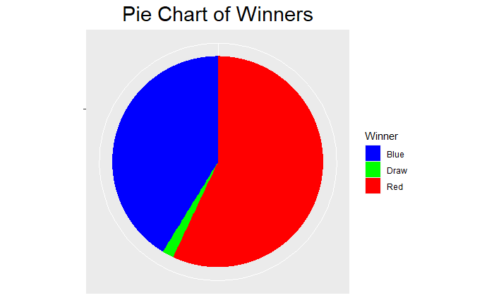

```r
custom_col <- c("blue", "green", "red")
ggplot(df2, aes(x = "", y="", fill = factor(Winner))) +
  geom_bar(width = 1, stat = "identity") +
  theme(axis.line = element_blank(),
        plot.title = element_text(hjust=0.5,size=22)) +
  labs(fill="Winner",
       x=NULL,
       y=NULL,
       title="Pie Chart of Winners") + coord_polar(theta = "y", start=0)+
  scale_fill_manual(values=custom_col)
```